# t-критерий Стьюдента

Тимофеев И., 391 группа

## Сравнение среднего процента брака на 1 и 5 заводах (t-тест) - задача 4, пункт 5

## Гипотезы

Нулевая гипотеза: процент брака на первом заводе не статистически значимо отличается от процента брака на пятом заводе.

Альтернативная гипотеза: процент брака на первом заводе статистически значимо отличается от процента брака на пятом заводе.

Уровень значимости $\alpha$ возьмем равным 0.05. Т.е. мы можем отклонить $H_0$ только, если вероятность ошибки при ее отклонении составляет меньше 0.05.

## Проверка

Сначала посмотрим на структуру наших данных:

```r
str(WasteRunUp_15_Update)
```

```
## 'data.frame':    35 obs. of  2 variables:
##  $ Num: num  11.5 20.4 8.3 11.8 7.3 9.6 13.5 13 7.1 8.6 ...
##  $ PT : Factor w/ 2 levels "PT1","PT5": 1 1 1 1 1 1 1 1 1 1 ...
```

```r
head(WasteRunUp_15_Update)
```

```
##    Num  PT
## 1 11.5 PT1
## 2 20.4 PT1
## 3  8.3 PT1
## 4 11.8 PT1
## 5  7.3 PT1
## 6  9.6 PT1
```

Эти данные получены из первоначального дата фрейма с пятью переменными и переведены в дата фрейм с двумя перменными: Num - процент брака, PT - завод к которому принадлежит измерение. А затем данные Num сдвинуты на $|min(Num)|+1$ вправо, чтобы не было отрицательных значений и нуля.

Затем построим график boxplot:

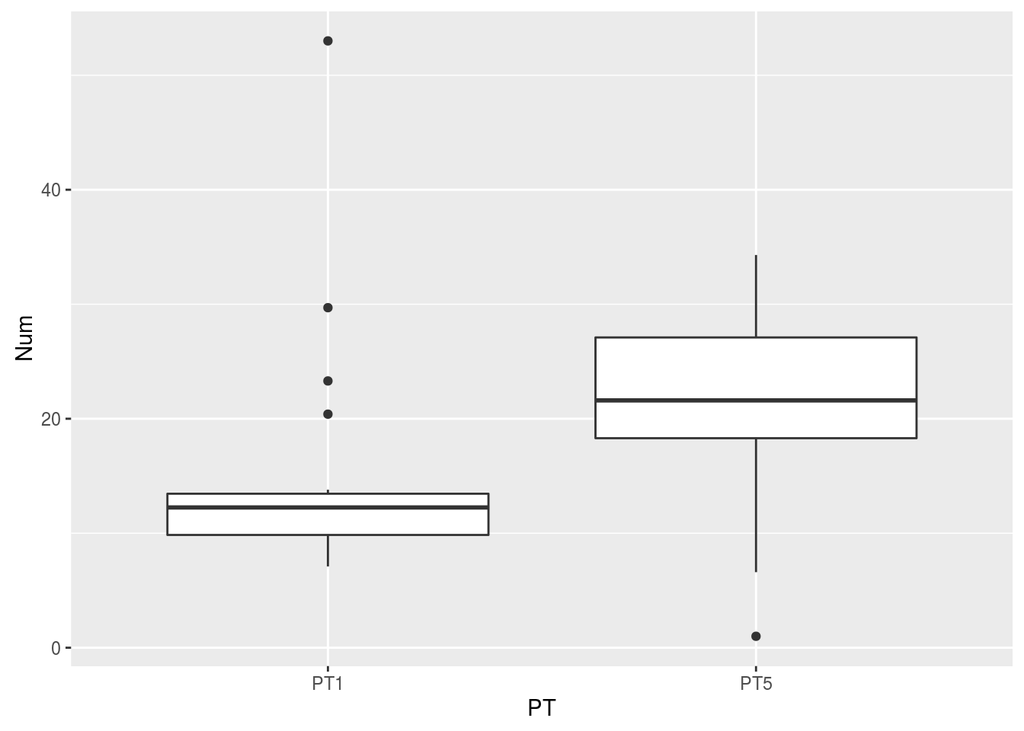

```r
boxplot_WRU_15_Up
```

Можно заметить, что значения для первого завода распределяются очень плохо(далеко от нормального) с большим количеством сильных выбросов, попробуем построить еще несколько графиков, чтобы дополнительно проиллюстрировать это.

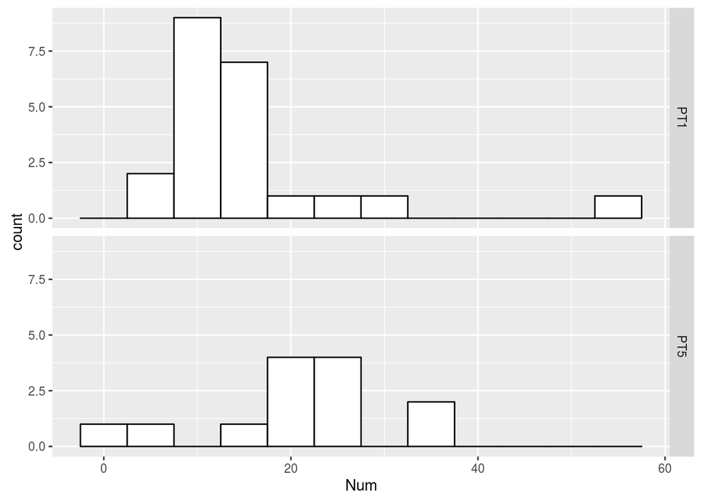

```r
hist_WRU_15_Up
```

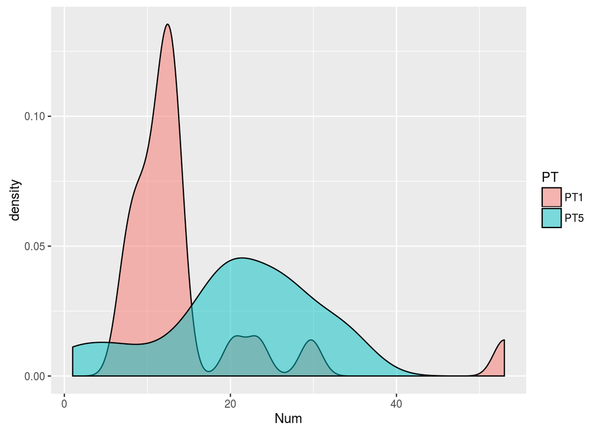

```r
density_WRU_15_Up
```

Теперь нужно проверить насколько в действительности его значения отклоняются от нормального, чтобы сделать окончательный вывод.

Шапиро тест для первого завода:

```r
shtest_PT1
```

```
##
##  Shapiro-Wilk normality test
##
## data:  WasteRunUp_15_Update$Num[PT == "PT1"]
## W = 0.62863, p-value = 2.743e-06
```

Значение p-value=2.743332910^{-6}, что намного меньше значения 0.05 или даже 0.01, т.е. позволяет нам отвергнуть нулевую гипотезу о том, что данное распределение совпадает с нормальным. Для пятого завода все не так плохо 0.6542587, но нам нужно, чтобы оба распределения были близки к нормальному.

Поробуем применить метод Бокса Кокса для приведения распределения PT1 к нормальному, но так как нам нужно сместить оба распределения одинаково, то придется применять метод к распределению всех значений, что может плохо сказать на результате.

Для начала посмотрим на общее распределение, чтобы сравнить его с результатом после применения метода.

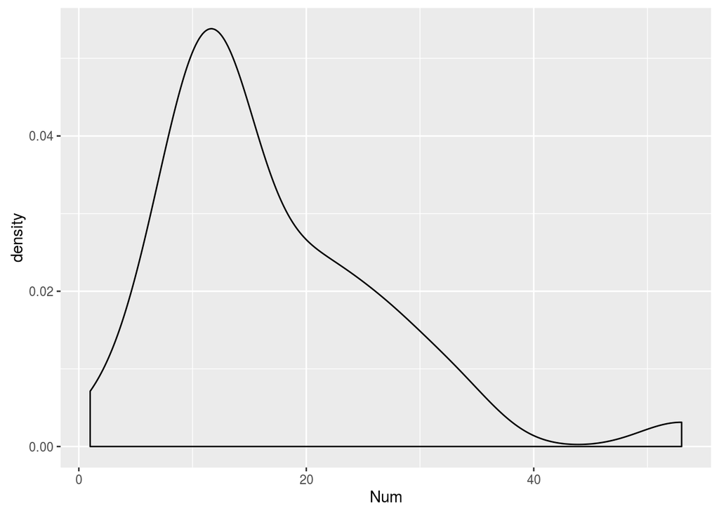

```r
density_WRU_15_Up_Num
```

Теперь найдем $\lambda$ для метода Бокса Кокса:

```r
Lambda_WasteRunUp_15_Update
```

```
## Box-Cox Transformation
##
## 35 data points used to estimate Lambda
##
## Input data summary:
##    Min. 1st Qu.  Median    Mean 3rd Qu.    Max.
##    1.00   11.05   13.30   17.00   22.10   53.00
##
## Largest/Smallest: 53
## Sample Skewness: 1.39
##
## Estimated Lambda: 0.4
```

Получили максимально удобное значение $\lambda$ равное 0.4 и по нему построили распределения.

Первые элементы получившегося распределения:

```r
head(WasteRunUp_15_Update_BoxCox)
```

```
##        Num  PT
## 1 4.140781 PT1
## 2 5.852031 PT1
## 3 3.328694 PT1
## 4 4.209541 PT1
## 5 3.036932 PT1
## 6 3.678009 PT1
```

Построим график для общего распределения:

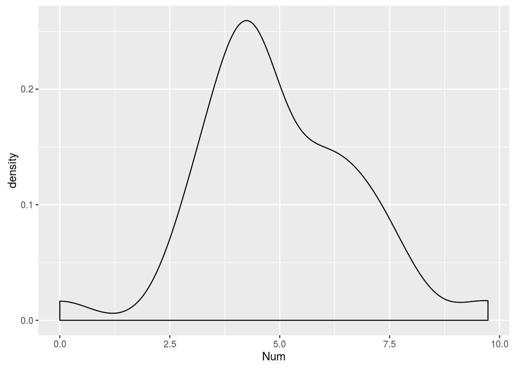

```r
density_WRU_15_Up_Num_BoxCox
```

Теперь построим boxplot, histogram и density для нового распределения:

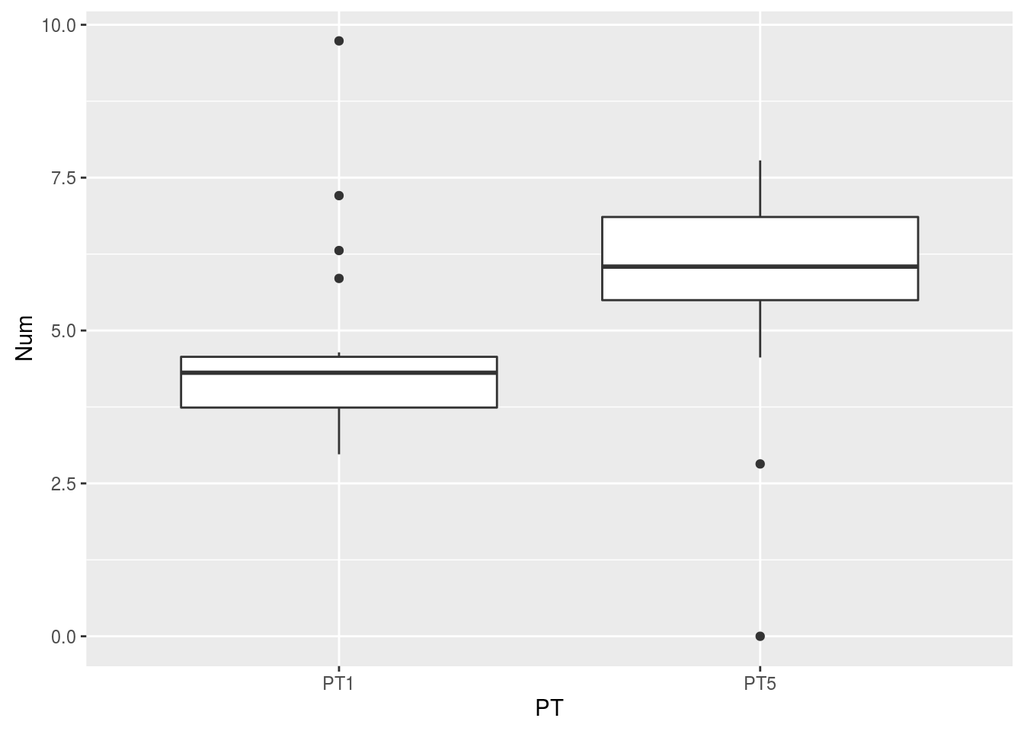

```r
boxplot_WRU_15_Up_BoxCox
```

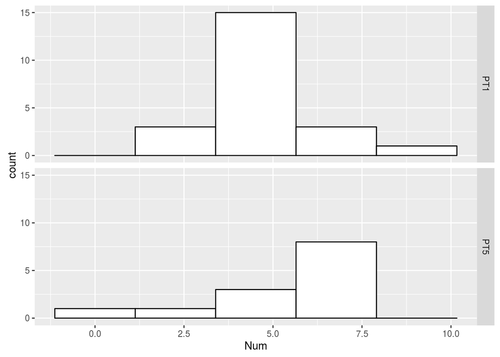

```r
hist_WRU_15_Up_BoxCox
```

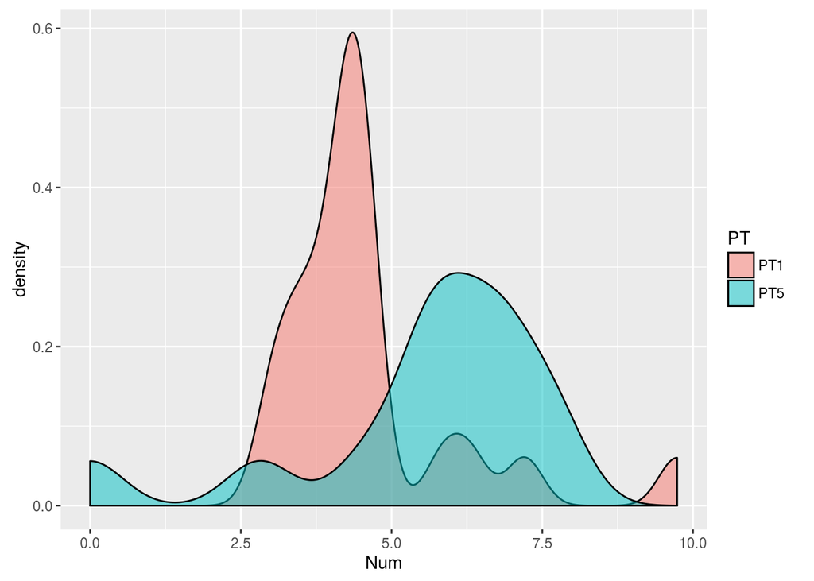

```r
density_WRU_15_Up_BoxCox
```

На графиках видно, что распределение у первого завода значительно улучшилось, в то время как у пятого все стало хуже. Проведем Шапиро тест для нового распределения:

```r
shtest_BoxCox_PT1
```

```
##
##  Shapiro-Wilk normality test
##
## data:  WasteRunUp_15_Update_BoxCox$Num[PT == "PT1"]
## W = 0.77394, p-value = 0.0002011
```

```r
shtest_BoxCox_PT5
```

```
##
##  Shapiro-Wilk normality test
##
## data:  WasteRunUp_15_Update_BoxCox$Num[PT == "PT5"]
## W = 0.83337, p-value = 0.01746
```

Значение p-value для первого завода составляет 2.010741410^{-4}, а для пятого 0.0174635, что означает, что нам не удасться преобразовать наши распределения общими методами так, чтобы они были достаточно близки к нормальным. По графикам было видно, что нормальности распределения сильно мешают большие выбросы, для такого случая может подойти U-test или Критерий Манна-Уитни, который вместо того, чтобы просто сравнивать средние значения распределений, сначала ранжирует эти значения, убирая зависимость от резких выбросов, а затем уже сравнивает средние.

```r
Utest_WasteRunUp_15_Update_BoxCox
```

```
##
##  Wilcoxon rank sum test with continuity correction
##
## data:  Num by PT
## W = 76, p-value = 0.02318
## alternative hypothesis: true location shift is not equal to 0
```

Результатом будет p значение равное 0.0231814, что меньше 0.05 и позволяет нам отклонить нулевую гипотезу $H_0$ о том, что распределения не отличаются на статистически значимую величину.

Теперь посмотрим на гомогенность дисперсии:

```r
disptest
```

```
##
##  Bartlett test of homogeneity of variances
##
## data:  Num by PT
## Bartlett's K-squared = 1.6691, df = 1, p-value = 0.1964
```

Значение p-value хорошее 0.196382>0.05, так что в t-test гомогенность дисперсии можно учитывать.

Для того, чтобы сравнить результат U-test и t-test, проведем последний:

```r
ttest
```

```
##
##  Two Sample t-test
##
## data:  Num by PT
## t = -1.5283, df = 33, p-value = 0.136
## alternative hypothesis: true difference in means is not equal to 0
## 95 percent confidence interval:
##  -2.1980148  0.3122708
## sample estimates:
## mean in group PT1 mean in group PT5
##          4.607599          5.550471
```

Итак значение величины p в критерии Стьюдента для распределения брака на 1 и 5 заводах составляет 0.1359573 > 0.05, что ожидаемо, т.к. распределения так и не были приведены к нормальным и сильные выбросы испортили картину.

Вывод: Мы выяснили, что распределения брака на 1 и 5 заводах действительно отличаются на статистически значимую величину, т.е. верна Альтернативная гипотеза. Но при этом t-test оказался неприменим в этой задаче.